# a5-data-report

Jareese Espinosa

11/12/19

## Summary Information

In the shootings-2018 data set there were 340 shooting events. There were 373 lives lost. With impact being in terms of the total amount of lives lost and injuries occurred, the city impacted the most was Chicago with the total amount of lives lost and injuries occurred being 135. Similarly two other insights in term of impact can be seen with state location and month dates. The state impacted the most was California with the total amount of lives lost and injuries occurred being 186. The month impacted the most was June with the total amount of lives lost and injuries occurred being 257.

## Summary Table

| Month | Injuries per Month | Deaths per Month | Total Injuries and Deaths per Month | Proportion Dead from Total Injuries and Deaths |
| --- | --- | --- | --- | --- |
| April | 88 | 27 | 115 | 23.48 |
| August | 152 | 21 | 173 | 12.14 |
| December | 61 | 13 | 74 | 17.57 |
| February | 62 | 43 | 105 | 40.95 |
| January | 87 | 23 | 110 | 20.91 |
| July | 184 | 42 | 226 | 18.58 |
| June | 218 | 39 | 257 | 15.18 |
| March | 68 | 10 | 78 | 12.82 |
| May | 121 | 30 | 151 | 19.87 |
| November | 62 | 50 | 112 | 44.64 |
| October | 116 | 40 | 156 | 25.64 |
| September | 128 | 35 | 163 | 21.47 |

## Description of a Particular Incident

In the data set an incident that stands out is the shooting that took place in Seattle (Skyway), as this is close to the area I grew up in and currently live. The shooting took place on April 29, 2018. In this tragic event 2 people were injured. Also there were 2 people who lost their lives. More information on this tragic event can be found at this link [Here](https://www.seattletimes.com/seattle-news/crime/two-men-killed-in-skyway-shooting-identified/).

## Interactive Map

Below is an interactive map that depicts the locations of various shootings. The map allows us to gather a better understanding of the geographical spread of these tragic incidents, where they tend to be in which areas of the country. Also the map displays the locations of these shootings via a blue dot that varies in size based on the amount of deaths and injuries occurred at each location (with the larger the circle the more people affected).

[interactive chart not shown]

Based on the visuals displayed in the map it can be seen that shootings occur not only more frequently but in more “severity” (injuries and deaths) in larger cites closer to coastal lines such as Chicago, Baltimore, Pompano Beach, New Orleans, Los Angeles, San Francisco, etc. These locations have the most amount of shooting incidents with the largest circles (meaning more deaths and injures). Also the Map reveals that shootings in the Pacific North West area (states such as Washington, Idaho, Montana, Oregon, etc.) have little to no shooting incidents at all. Even the few incidents that occurred are small in size meaning the rare shootings in this area of the country had relatively low deaths and injuries compared to other areas.

## A plot

Below is a plot depicting the amount of total injuries on the y-axis and total deaths on the x-axis per each state. This plot helps us to address the question of which state was impacted the most.

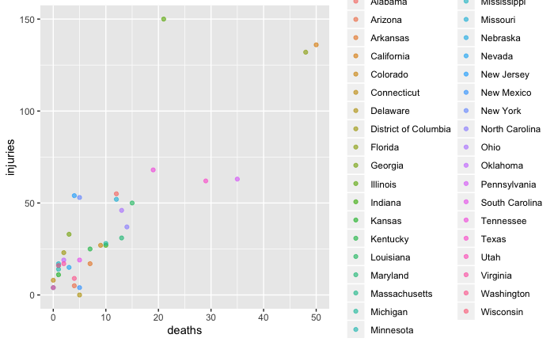

Based on the plot above it can be clearly seen that Illinois, California, and Florida have many more injuries from shooting related incidents than any other state. However California and Florida have by far the most deaths from shooting related incidents than any other state. This means that while Illinois has many injuries the death toll is not as severe compared to the other states. Also because Florida and California are in the top three for both injury count and death count from shootings, this means that they have by far the most people impacted (shot or dead) from shooting related incidents as they are the most top right points in the chart. On the opposite side Utah can be found in as the point furthest to the bottom left side of chart. This means they have the lowest death and injury count total. This could be due to the strong religious ties in Utah compared to the more populated, and thus more dangerous due to more crime chances, states of Florida and California.

## Critical Reflection

Data related to mass shootings can provide virtue in regulating crime. As O’neil depicts, models like PredPol are predicting where crime is likely to occur based on geographical data as to where crime is occurring, similar to how the plot created above depicts where crime occurs in terms of states (geographic input) and we can assume shootings are more likely to occur in Florida and California. However by regulating these more dangerous areas leads to a harmful feedback loop in which crime is more thoroughly documented in these areas so it appears as crime is occurring more in these geographic locations, making resource distribution disproportionate.